# R Studies - 2. Lab Introduction to R

This notebook is a set of studies for the book “An Introduction To Statistical Learning - second Edition”. The series of notebooks start at the second chapter - Statistical Learning - since the first chapter does not have any R exercises.

Before starting, R can be downloaded from

http://cran.r-project.org.

This notebook is written and build using RStudio, which can be freely downloaded from

http://rstudio.com.

## 2.3.1 Basic Commands

The following command instructs R to join together the numbers 1, 2, 3, and 5, and to save them as a vector named `x`. When we type `x`, it gives us back the vector.

```r
x <- c(1,3,2,5)
x
```

```
[1] 1 3 2 5
```

We can also save things using `=` rather than `<-`:

```r
x = c(1,6,2)
y = c(1,4,3)
c(x,y)
```

```
[1] 1 6 2 1 4 3
```

In additions, typing `?funcname` will cause R to open a new help file window with additional information about the function `funcname()`. We can check a variable length using the `length()` function.

```r
length(x)
```

```
[1] 3
```

```r
length(y)
```

```
[1] 3
```

```r
x+y
```

```
[1]  2 10  5
```

The `ls()` function allow us to look at a list of all of the objects, such as data and functions, that we have saved so far. The `rm()` function can be used to delete any that we don’t want.

```r
ls()
```

```
[1] "Auto" "f"    "fa"   "x"    "y"
```

```r
rm(x,y)
```

And is also possible to remove all objects at once:

```r
rm(list=ls())
```

The `matrix()` function will be essential to use algebra in our statistical learning. The function takes a `data` parameter and a number of rows and columns that will compose the matrix.

```r
x <- matrix(data = c(1,2,3,4),nrow = 2, ncol = 2)
x
```

```
     [,1] [,2]
[1,]    1    3
[2,]    2    4
```

We don’t need to specify the name of the parameters once that we put them in the correct order.

```r
x <- matrix(c(1,2,3,4),2,2)
x
```

```
     [,1] [,2]
[1,]    1    3
[2,]    2    4
```

By default `R` creates matrices by successively filling in columns. Alternatively the `byrow = TRUE` option can be used to populate the matrix in order of the rows.

```r
matrix(c(1,2,3,4),2,2,byrow = TRUE)
```

```
     [,1] [,2]
[1,]    1    2
[2,]    3    4
```

We can get the square root of a number, a vector or a matrix with the function `sqrt()`.

```r
sqrt(x)
```

```
         [,1]     [,2]
[1,] 1.000000 1.732051
[2,] 1.414214 2.000000
```

Similarly, we can get the value of each element powered by two:

```r
x^2
```

```
     [,1] [,2]
[1,]    1    9
[2,]    4   16
```

The `rnorm()` function generates a vector of random normal variables, with first argument `n` the sample size. Each time we call this function, we will get a different answer.

```r
x<-rnorm(50)
x;
```

```
 [1] -1.25937879  0.76298729 -0.80345354 -0.37938392 -1.36649429  3.51929906 -1.21314850  0.19435732
 [9]  0.09436564 -0.87849142  0.26043586  0.65770706  0.76579653 -2.23536063 -0.90282612 -0.16638383
[17] -0.06549942 -0.50563802  0.52028671  0.03570148 -0.91068956  0.91434312 -0.33670912  0.09476286
[25]  2.12722072  0.19658448 -0.96760474 -0.28489724  0.16444600 -1.11187081 -1.92936482 -0.47026086
[33]  0.53438783 -0.92104994  0.68437435  1.52207877  0.19461330  1.69722472  0.27806819 -0.57101046
[41] -0.15787944  2.48833935  1.07136909  0.34221908  0.22132743  0.06836274  0.30742160  1.50863386
[49]  0.61584224  0.08981202
```

We create two correlated sets of numbers, `x` and `y`, and use the `cor()` function to compute the correlation between them.

```r
y <- x + rnorm(50,mean=50, sd = .1)
cor(x,y)
```

```
[1] 0.995529
```

We can set the a seed to reproduce the exact same set of random numbers: we can use the `set.seed()` function to do this.

```r
set.seed(1303)
rnorm(50)
```

```
 [1] -1.1439763145  1.3421293656  2.1853904757  0.5363925179  0.0631929665  0.5022344825 -0.0004167247
 [8]  0.5658198405 -0.5725226890 -1.1102250073 -0.0486871234 -0.6956562176  0.8289174803  0.2066528551
[15] -0.2356745091 -0.5563104914 -0.3647543571  0.8623550343 -0.6307715354  0.3136021252 -0.9314953177
[22]  0.8238676185  0.5233707021  0.7069214120  0.4202043256 -0.2690521547 -1.5103172999 -0.6902124766
[29] -0.1434719524 -1.0135274099  1.5732737361  0.0127465055  0.8726470499  0.4220661905 -0.0188157917
[36]  2.6157489689 -0.6931401748 -0.2663217810 -0.7206364412  1.3677342065  0.2640073322  0.6321868074
[43] -1.3306509858  0.0268888182  1.0406363208  1.3120237985 -0.0300020767 -0.2500257125  0.0234144857
[50]  1.6598706557
```

The `mean()` and `var()` functions can be used to compute the mean and variance of a vector of numbers. We can apply `sqrt()` after the `var()` function to have the standard deviation or simply use the `sd()` function.

```r
set.seed(3)
y <- rnorm(100)
cat("Mean:",mean(y),"\nVar:",var(y),"\nSqrt(Var):",sqrt(var(y)),"\nStandard Deviation:",sd(y))
```

```
Mean: 0.01103557
Var: 0.7328675
Sqrt(Var): 0.8560768
Standard Deviation: 0.8560768
```

## 2.3.2 Graphics

The `plot()` function is the primary way to plot data in `R`. For instance, `plot(x,y)` produces a scatter plot of the numbers `x` versus the numbers in `y`. Passing in the argument `xlab` will result in a label on the x-axis.

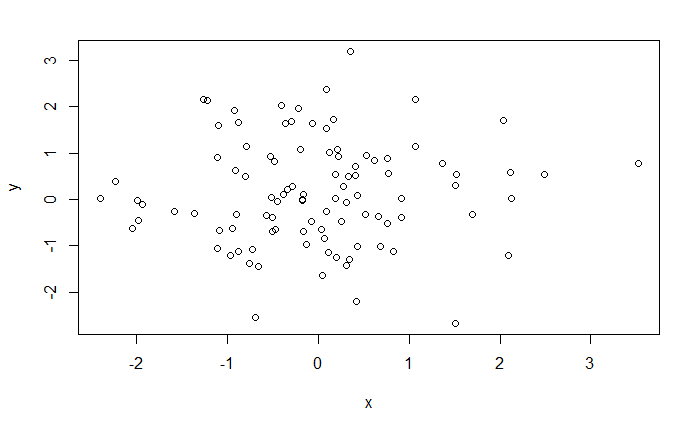

```r
x <- rnorm(100)
y <- rnorm(100)
plot(x, y)
```

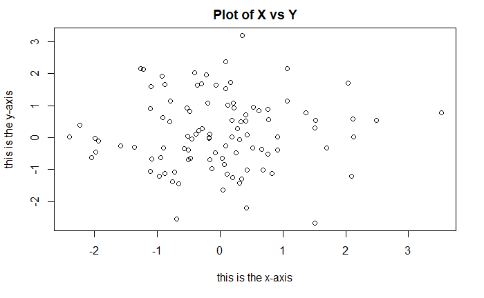

```r
plot(x, y, xlab = "this is the x-axis",
     ylab = "this is the y-axis",
     main = "Plot of X vs Y")
```

We will often want to save the output of an R plot. For example, we can use the function `pdf()` to create a pdf - and, for instance, if you want to create a jpeg, you can use `jpeg()`.

```r
pdf("Figure.pdf")
plot(x,y,col = "green")
dev.off()
```

The function `dev.off()` indicates to R that we are done creating the plot. The function `seq()` can be used to create a sequence of numbers. For example, `seq(a,b)` makes a vector of integers between `a` and `b`. We can explore more of the `seq()` function and see, for instance the `seq(0, 1, length = 10)` property to make a sequence of 10 numbers equally spaced between 0 and 1.

```r
seq(1, 10)
```

```
 [1]  1  2  3  4  5  6  7  8  9 10
```

We can type `3:11` as a shorthand for `seq(3,11)` for integers arguments. We will now create some more sophisticated plots. The `outer()` function produces a matrix using the values of arrays as columns and rows and a function to populate the matrix. The `countour()` function produces a *countour plot* in order to represent three-dimensional data; it is like a topographical map. * It takes three arguments: + A vector of the **x** values (the first dimension), + A vector of the **y** values (the second dimension), and + A matrix whose elements correspond to the **z** value (the third dimension) for each pair of (**x**,**y**) coordinates.

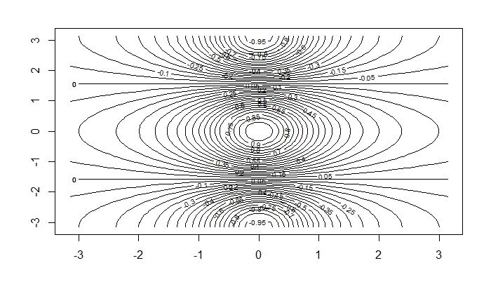

```r
x <- seq(-pi, pi, length = 50)
y <- x
f <- outer(x,y, function(x,y) cos(y)/(1+x^2))
contour(x, y, f)
contour(x, y, f, nlevels = 45, add = T)
```

The **t()** function makes the transpose of a given matrix or data frame.

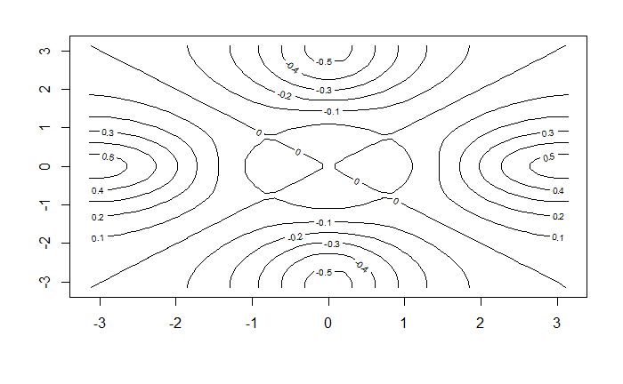

```r
fa  <- (f - t(f))/2
contour(x, y, fa, nlevels = 15)
```

The `image()` function works the same way as `contour()`, except is a color-coded plot whose colors depend on the **z** value - this is known as *heatmap*. The `persp()` can be used to produce a three-dimensional plot, we can pass the arguments **theta** and **phi** to control the view angles of the plot.

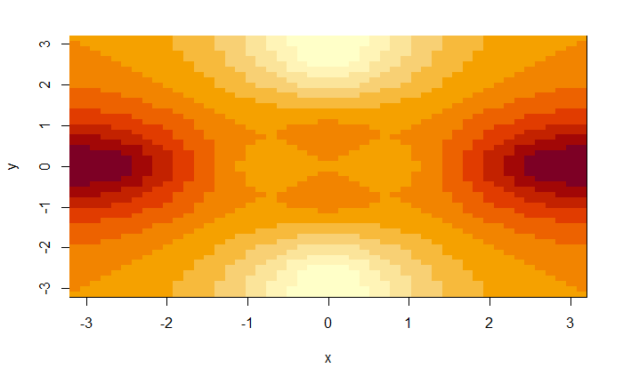

```r
image(x, y, fa)
```

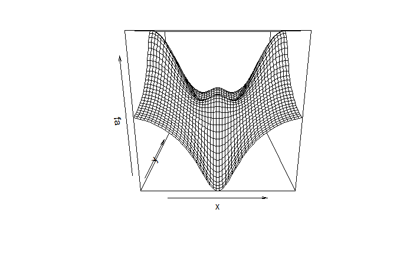

```r
persp(x, y, fa)
```

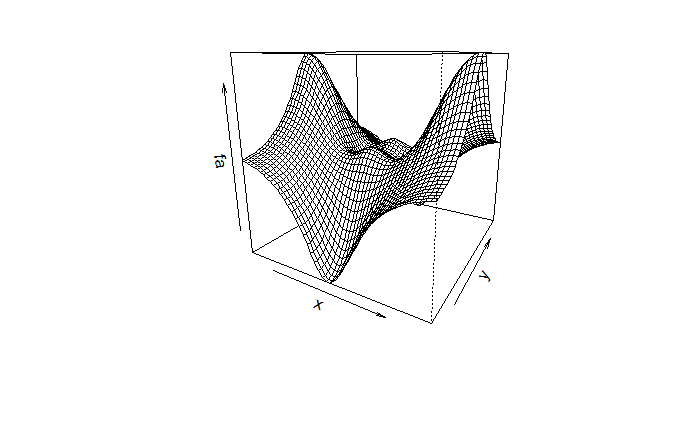

```r
persp(x, y, fa, theta = 30)
```

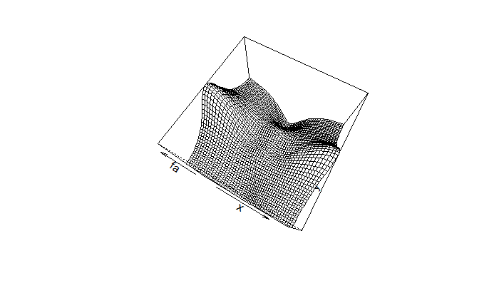

```r
persp(x,y,fa, theta = 30, phi = 70)
```

## 2.3.4 Loading Data

As almost every statistical learning project, one of the first steps involves importing a data set into the code. In R, the most simple way of loading data is the `read.table()` function. In the other way around, the `write.table()` function allows us to quickly write data into a file.

The following command will load the **Auto.data** file into **R** and store it as an object called **Auto**, in a format referred to as *data frame*. Once you loaded the data as a data frame, you can use the function `View()` to view the data in a spreadsheet-like window. The `head()` function can also be used to view the first few rows of the data - which can be more practical if you only want to see the format of a data frame.

```r
Auto <- read.table("data/Auto.data")
View(Auto)
head(Auto)
```

|  | V1 | V2 | V3 | V4 | V5 | V6 | V7 | V8 | V9 |
| --- | --- | --- | --- | --- | --- | --- | --- | --- | --- |
| 1 | mpg | cylinders | displacement | horsepower | weight | acceleration | year | origin | name |
| 2 | 18.0 | 8 | 307.0 | 130.0 | 3504. | 12.0 | 70 | 1 | chevrolet chevelle malibu |
| 3 | 15.0 | 8 | 350.0 | 165.0 | 3693. | 11.5 | 70 | 1 | buick skylark 320 |
| 4 | 18.0 | 8 | 318.0 | 150.0 | 3436. | 11.0 | 70 | 1 | plymouth satellite |
| 5 | 16.0 | 8 | 304.0 | 150.0 | 3433. | 12.0 | 70 | 1 | amc rebel sst |
| 6 | 17.0 | 8 | 302.0 | 140.0 | 3449. | 10.5 | 70 | 1 | ford torino |

The data set above has not been loaded correctly, because **R** has assumed that the variable names are part of the data and so has included them in the first row. We can use the parameter `header = T` (or `header = True`) in the `read.table()` to tell **R** that the first line of the files contains the variable names. Another option is to tell **R** that any time it sees a particular character or set of characters (such as a question mark), it should treat it as a missing element of the data matrix - in this example, we set **?** as a NaN value with `na.strings ="?"`.

```r
Auto <- read.table("data/Auto.data", header = T, na.strings = "?",
                   stringsAsFactors = T)
head(Auto)
```

|  | mpg | cylinders | displacement | horsepower | weight | acceleration | year | origin | name |
| --- | --- | --- | --- | --- | --- | --- | --- | --- | --- |
| 1 | 18 | 8 | 307 | 130 | 3504 | 12.0 | 70 | 1 | chevrolet chevelle malibu |
| 2 | 15 | 8 | 350 | 165 | 3693 | 11.5 | 70 | 1 | buick skylark 320 |
| 3 | 18 | 8 | 318 | 150 | 3436 | 11.0 | 70 | 1 | plymouth satellite |
| 4 | 16 | 8 | 304 | 150 | 3433 | 12.0 | 70 | 1 | amc rebel sst |
| 5 | 17 | 8 | 302 | 140 | 3449 | 10.5 | 70 | 1 | ford torino |
| 6 | 15 | 8 | 429 | 198 | 4341 | 10.0 | 70 | 1 | ford galaxie 500 |

We can also tell **R** to treat any variable containing character strings to be interpreted as a qualitative variable with `stringsAsFactros = T`.

An easy way to load data from Excel into **R** is to use the `read.casv()` function.

```r
Auto <- read.csv("data/Auto.csv", na.strings = "?",
                 stringsAsFactors = T)
head(Auto)
```

|  | mpg | cylinders | displacement | horsepower | weight | acceleration | year | origin | name |
| --- | --- | --- | --- | --- | --- | --- | --- | --- | --- |
| 1 | 18 | 8 | 307 | 130 | 3504 | 12.0 | 70 | 1 | chevrolet chevelle malibu |
| 2 | 15 | 8 | 350 | 165 | 3693 | 11.5 | 70 | 1 | buick skylark 320 |
| 3 | 18 | 8 | 318 | 150 | 3436 | 11.0 | 70 | 1 | plymouth satellite |
| 4 | 16 | 8 | 304 | 150 | 3433 | 12.0 | 70 | 1 | amc rebel sst |
| 5 | 17 | 8 | 302 | 140 | 3449 | 10.5 | 70 | 1 | ford torino |
| 6 | 15 | 8 | 429 | 198 | 4341 | 10.0 | 70 | 1 | ford galaxie 500 |

```r
dim(Auto)
```

```
[1] 397   9
```

The `dim()` function tells us that the data has 397 observations, or rows, and nine variables, or columns. We can slice a data frame as we would slice a collection.

```r
Auto[1:4, ]
```

|  | mpg | cylinders | displacement | horsepower | weight | acceleration | year | origin | name |
| --- | --- | --- | --- | --- | --- | --- | --- | --- | --- |
| 1 | 18 | 8 | 307 | 130 | 3504 | 12.0 | 70 | 1 | chevrolet chevelle malibu |
| 2 | 15 | 8 | 350 | 165 | 3693 | 11.5 | 70 | 1 | buick skylark 320 |
| 3 | 18 | 8 | 318 | 150 | 3436 | 11.0 | 70 | 1 | plymouth satellite |
| 4 | 16 | 8 | 304 | 150 | 3433 | 12.0 | 70 | 1 | amc rebel sst |

There are various ways to deal with the missing data. In this case, only five of the rows contain missing observations, and so we choose to use the `na.omit()` function to simply remove these rows.

```r
Auto <- na.omit(Auto)
dim(Auto)
```

```
[1] 392   9
```

We can use the `names()` function to check the variable names.

```r
names(Auto)
```

```
[1] "mpg"          "cylinders"    "displacement" "horsepower"   "weight"       "acceleration" "year"
[8] "origin"       "name"
```

## 2.3.5 Additional Graphical and Numerical Summaries

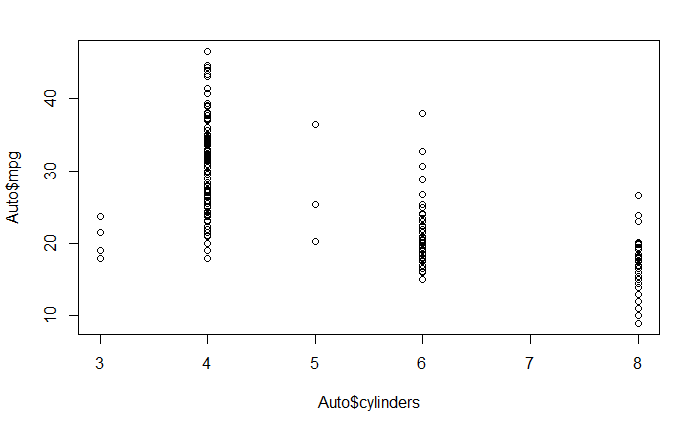

```r
plot(Auto$cylinders, Auto$mpg)
```

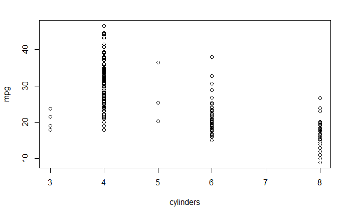

```r
attach(Auto)
plot(cylinders, mpg)
```

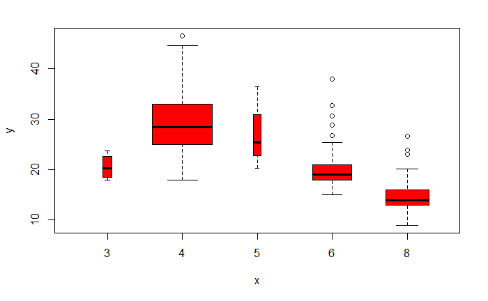

```r
cylinders <- as.factor(cylinders)
plot(cylinders, mpg, col = "red", varwidth = T)
```

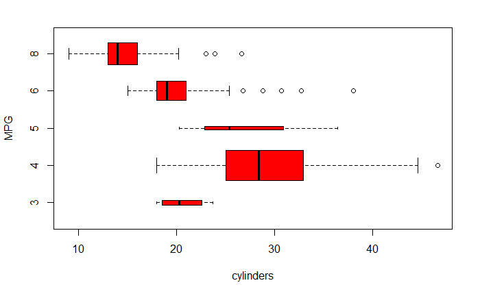

```r
plot(cylinders, mpg,  varwidth = T, horizontal = T,
     col = "red", xlab = "cylinders", ylab = "MPG", )
```

### References

1. James, G.; Witten, D.; Hastie, T.; Tibshirani, R. **An Introduction to Statistical Learning - Second Edition**. Springer, 2021.